# SurvBoost: An R Package for High-Dimensional Variable Selection in the Stratified Proportional Hazards Model via Gradient Boosting

This option iterates until the specified number of variables, 5 in this example, are selected. See methods for other stopping criteria. Note that in the package BIC and EBIC are available jointly in one option when *control_method* is set to "BIC". Setting the parameter $\gamma = 0$ will reduce the EBIC penalty to the BIC penalty. In order to implement EBIC, a nonzero value of gamma should be specified in *control_parameter*.  
The `plot.boosting()` function displays a plot of the selection frequency by the number of iterations. Another option of the `plot.boosting()` function is to plot the coefficient paths of each variable by the number of boosting iterations. See Figures 2 and 3.

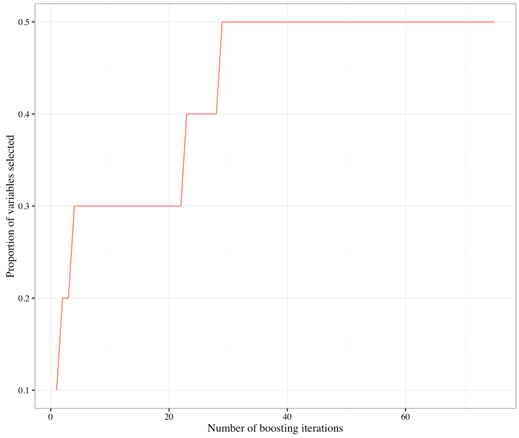

Figure 2: Plot generated by `plot.boosting` function, variable selection frequency by number of boosting iterations.

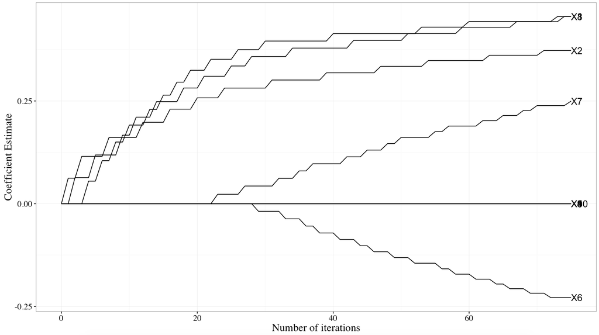

Figure 3: Plot generated by `plot.boosting` function with option “coefficients,” coefficient paths for variables selected by number of boosting iterations.

The function `predict.boosting()` provides an estimate of the hazard ratio for each observation in the dataset provided, relative to the average of $p$ predictors.

```r
R > predict.boosting(test1)[1:6]
46.385476  1.823920 42.049932 16.427860  4.013200  2.243711
```

The model selected using boosting can be refit with `coxph()` for post selection inference. The function `post.selection.fitting.boosting()` will perform this refitting and output the coefficient estimates with corresponding standard errors and p-values. Note that the statistical inferences performed here are conditional on the variable selection results. The interpretation of p-values and standard errors are fundamentally different from the regular unconditional statistical inferences. The performance of conditional statistical inferences is highly dependent on the variable selection accuracy. In our case, it depends on the choice of stopping rule.

```r
R > summary.test1 <- summary.boosting(test1)
R > fmla <- summary.test1$formula
R > post.selection.fitting.boosting(fmla, data=data_small)
Call:
coxph(formula = fmla, data = data)

  n = 506, number of events = 371

       coef exp(coef) se(coef)      z Pr(>|z|)
V1  0.59181   1.80726  0.07454  7.940 2.00e-15 ***
V2  0.48079   1.61736  0.06948  6.920 4.53e-12 ***
V6 -0.51830   0.59553  0.07145 -7.254 4.05e-13 ***
V7  0.51108   1.66709  0.08479  6.028 1.66e-09 ***
V8  0.54758   1.72907  0.07116  7.695 1.42e-14 ***
---
Signif. codes:  0 '***' 0.001 '**' 0.01 '*' 0.05 '.' 0.1 ' ' 1

   exp(coef) exp(-coef) lower .95 upper .95
V1    1.8073     0.5533    1.5616    2.0915
V2    1.6174     0.6183    1.4114    1.8533
V6    0.5955     1.6792    0.5177    0.6851
V7    1.6671     0.5998    1.4118    1.9685
V8    1.7291     0.5783    1.5040    1.9879

Concordance= 0.762  (se = 0.036 )
Rsquare= 0.487   (max possible= 0.997 )
Likelihood ratio test= 338.1  on 5 df,   p=0
Wald test            = 287.8  on 5 df,   p=0
Score (logrank) test = 299.1  on 5 df,   p=0
```

## 5 TCGA data example

Data from three breast cancer cohorts was used to demonstrate this method on data outside of the simulation framework. There were 578 patients included in the combined data, with 8,864 variables measured for each patient: 8,859 genes and 5 phenotypic variables. The phenotype variables included age at diagnosis, tumor size, cancer stage, progesterone-receptor status, and estrogen-receptor status. The data can be downloaded from The Cancer Genome Atlas (TCGA) (Miller et al. 2005; Chin et al. 2006; Naderi et al. 2006) or from GitHub using the following R code.

```r
R > library(piggyback)
R > pb_download("data.tcga.tsv.gz",
            repo = "EmilyLMorris/survBoost")
R > data <- read_tsv("data.tcga.tsv")
```

The patients were split into two cohorts depending on their cancer stage and tumor size. One cohort contained patients with a less severe prognosis, cancer stage of one and tumor size less than the median; the other cohort contained those with cancer stage greater than one and/or with a tumor larger than the median size.

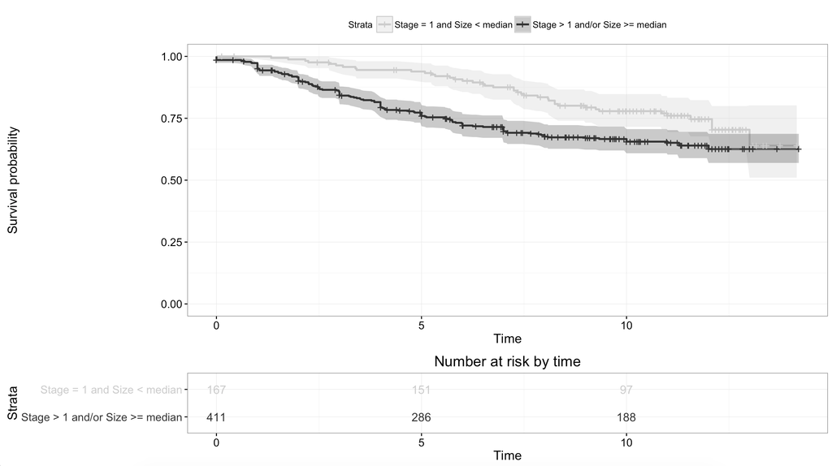

Figure 4: Survival curves for the two strata based on cancer stage and tumor size.

```r
R > fit.plot <- survfit(Surv(survival_time, survival_ind) ~ as.factor(severity), data=data)
R > ggsurvplot(fit.plot,
           conf.int = TRUE,
           risk.table = TRUE,
           risk.table.col="strata",
           ggtheme = theme_bw(), palette = "grey")
```

This plot demonstrates that the proportional hazards assumption may not hold in this case. Stratifying based on this criteria generates the following results.  
Using stability selection (Meinshausen and Bühlmann 2010), 14 variables were identified with selection frequencies greater than 50% from 50 iterations of subsampling. Age and progesterone-receptor status were selected in addition to 12 genes. The boosting algorithm was performed with the number of iterations fixed at the sample size of 578.

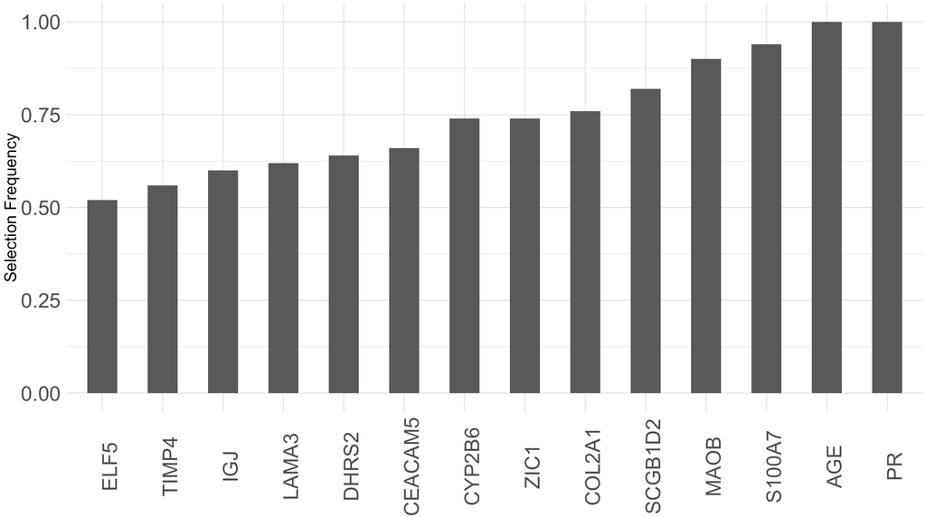

Figure 5: Selection frequencies for genes or phenotype variables that were selected at least 50% of the time with stability selection.

Several of the genes selected in this analysis have been previously identified as having an association with breast cancer. Psoriasin (S100A7) has been associated with breast cancer (Al-Haddad et al. 1999). Several studies have found COL2A1 to be part of gene signatures for predicting tumor recurrence (Wang et al. 2005; Yu et al. 2007). Other genes selected that have been identified as part of a gene signature or association with breast cancer tumor progression risk include: ZIC1 (Boersma et al. 2008), CYP2B6 (Tozlu et al. 2006), ELF5 (Chakrabarti et al. 2012–), IGJ (Boersma et al. 2008), DHRS2 (Krijgsman et al. 2012), and CEACAM5 (Blumenthal et al. 2007). *Mboost* using the same criteria but without a stratified model only identifies one gene of importance, MC2R, demonstrating the utility of the SPH model in this context.

## 6 Conclusion

In this article, we introduce a new R package *SurvBoost* which implements the gradient boosting algorithm for high-dimensional variable selection in the stratified proportional hazards (SPH) model, while most existing R packages, such as *mboost* only focus on the proportional hazards model. In the simulation studies, we show that *SurvBoost* can improve the model fitting and achieve better variable selection accuracy for the data with stratified structures. In addition, we optimize the implementations of the gradient boosting in both the SPH and the PH models. For the PH model fitting, *SurvBoost* can reduce about 30%-50% computational time compared to *mboost*. In the future, we plan to extend the package to handle more complex survival data such as left-truncation data and interval censoring data.

## 7 Acknowledgments

The authors would like to thank the editor and reviewers for suggestions that led to an improved manuscript. This work was partially supported by the NIH grants R01MH105561 (Kang) and R01GM124061 (Kang).

### 7.1 Supplementary materials

Supplementary materials are available in addition to this article. It can be downloaded at RJ-2020-018.zip

### 7.2 CRAN packages used

mboost, survival, Rcpp, RcppArmadillo, RcppParallel

### 7.3 CRAN Task Views implied by cited packages

ClinicalTrials, Econometrics, HighPerformanceComputing, MachineLearning, NumericalMathematics, Survival

S. Al-Haddad, Z. Zhang, E. Leygue, L. Snell, A. Huang, Y. Niu, T. Hiller-Hitchcock, K. Hole, L. C. Murphy and P. H. Watson. Psoriasin (S100A7) expression and invasive breast cancer. *The American journal of pathology*, 155(6): 2057–2066, 1999.

J. Allaire, R. Francois, K. Ushey, G. Vandenbrouck, M. Geelnard and Intel. *RcppParallel: Parallel programming tools for ’rcpp’.* 2018. URL https://CRAN.R-project.org/package=RcppParallel. R package version 4.4.0.

R. D. Blumenthal, E. Leon, H. J. Hansen and D. M. Goldenberg. Expression patterns of CEACAM5 and CEACAM6 in primary and metastatic cancers. *BMC Cancer*, 7(1): 2, 2007. URL https://doi.org/10.1186/1471-2407-7-2.

B. J. Boersma, M. Reimers, M. Yi, J. A. Ludwig, B. T. Luke, R. M. Stephens, H. G. Yfantis, D. H. Lee, J. N. Weinstein and S. Ambs. A stromal gene signature associated with inflammatory breast cancer. *International Journal of Cancer*, 122(6): 1324–1332, 2008. URL https://doi.org/10.1002/ijc.23237.

P. Bühlmann and T. Hothorn. Boosting algorithms: Regularization, prediction and model fitting (with discussion). *Statistical Science*, 22(4): 477–505, 2007.

P. Bühlmann and B. Yu. Boosting. *Wiley Interdisciplinary Reviews: Computational Statistics*, 2(1): 69–74, 2010. URL https://doi.org/10.1002/wics.55.

R. Chakrabarti, J. Hwang, M. A. Blanco, Y. Wei, M. Lukacisin, R.-A. Romano, K. Smalley, S. Liu, Q. Yang, T. Ibrahim, et al. Elf5 inhibits the epithelial-mesenchymal transition in mammary gland development and breast cancer metastasis by transcriptionally repressing snail2. *Nature Cell Biology*, 14: 1212–1222, 2012–.

K. Chin, S. DeVries, J. Fridlyand, P. T. Spellman, R. Roydasgupta, W.-L. Kuo, A. Lapuk, R. M. Neve, Z. Qian, T. Ryder, et al. Genomic and transcriptional aberrations linked to breast cancer pathophysiologies. *Cancer Cell*, 10(6): 529–541, 2006. URL https://doi.org/10.1016/j.ccr.2006.10.009.

D. Eddelbuettel, R. Francois, J. Allaire, K. Ushey, Q. Kou, N. Russell, D. Bates and J. Chambers. *Rcpp: Seamless r and c++ integration.* 2018a. URL https://CRAN.R-project.org/package=Rcpp. R package version 0.12.15.

D. Eddelbuettel, R. Francois, D. Bates and B. Ni. *RcppArmadillo: ’Rcpp’ integration for the ’armadillo’ templated linear algebra library.* 2018b. URL https://CRAN.R-project.org/package=RcppArmadillo. R package version 0.8.400.0.0.

J. J. Goeman. L1 penalized estimation in the cox proportional hazards model. *Biometrical Journal*, 52(1): 70–84, 2010. DOI 10.1002/bimj.200900028.

K. He, Y. Li, J. Zhu, H. Liu, J. E. Lee, C. I. Amos, T. Hyslop, J. Jin, H. Lin, Q. Wei, et al. Component-wise gradient boosting and false discovery control in survival analysis with high-dimensional covariates. *Bioinformatics*, 32(1): 50–57, 2016. URL https://doi.org/10.1093/bioinformatics/btv517.

B. Hofner, A. Mayr, N. Robinzonov and M. Schmid. Model-based boosting in R: A hands-on tutorial using the R package mboost. *Computational Statistics*, 29: 3–35, 2014.

T. Hothorn, P. Buehlmann, T. Kneib, M. Schmid and B. Hofner. *Mboost: Model-based boosting.* 2017. URL https://CRAN.R-project.org/package=mboost. R package version 2.8-1.

W. Jiang. Process consistency for AdaBoost. *Ann. Statist.*, 32(1): 13–29, 2004. URL https://doi.org/10.1214/aos/1079120128.

O. Krijgsman, P. Roepman, W. Zwart, J. S. Carroll, S. Tian, F. A. de Snoo, R. A. Bender, R. Bernards and A. M. Glas. A diagnostic gene profile for molecular subtyping of breast cancer associated with treatment response. *Breast Cancer Research and Treatment*, 133(1): 37–47, 2012. URL https://doi.org/10.1007/s10549-011-1683-z.

N. Meinshausen and P. Bühlmann. Stability selection. *Journal of the Royal Statistical Society: Series B (Statistical Methodology)*, 72(4): 417–473, 2010. URL http://dx.doi.org/10.1111/j.1467-9868.2010.00740.x.

L. D. Miller, J. Smeds, J. George, V. B. Vega, L. Vergara, A. Ploner, Y. Pawitan, P. Hall, S. Klaar, E. T. Liu, et al. An expression signature for p53 status in human breast cancer predicts mutation status, transcriptional effects, and patient survival. *Proceedings of the National Academy of Sciences of the United States of America*, 102(38): 13550–13555, 2005. URL https://doi.org/10.1073/pnas.0506230102.

A. Naderi, A. E. Teschendorff, N. L. Barbosa-Morais, S. E. Pinder, A. R. Green, D. G. Powe, J. F. R. Robertson, S. Aparicio, I. O. Ellis, J. D. Brenton, et al. A gene-expression signature to predict survival in breast cancer across independent data sets. *Oncogene*, 26: 1507–1516, 2006.

N. Simon, J. Friedman, T. Hastie and R. Tibshirani. Regularization paths for cox’s proportional hazards model via coordinate descent. *Journal of Statistical Software, Articles*, 39(5): 1–13, 2011. URL https://doi.org/10.18637/jss.v039.i05.

T. M. Therneau. *Survival: Survival analysis.* 2017. URL https://CRAN.R-project.org/package=survival. R package version 2.41-3.

R. Tibshirani. The lasso method for variable selection in the cox model. *Statistics in medicine*, 16(4): 385–395, 1997.

S. Tozlu, I. Girault, S. Vacher, J. Vendrell, C. Andrieu, F. Spyratos, P. Cohen, R. Lidereau and I. Bieche. Identification of novel genes that co-cluster with estrogen receptor alpha in breast tumor biopsy specimens, using a large-scale real-time reverse transcription-PCR approach. *Endocrine-Related Cancer*, 13(4): 1109–1120, 2006. URL https://doi.org/10.1677/erc.1.01120.

C. T. Volinsky and A. E. Raftery. Bayesian information criterion for censored survival models. *Biometrics*, 56(1): 256–262, 2000. URL https://doi.org/10.1111/j.0006-341X.2000.00256.x.

Y. Wang, J. G. Klijn, Y. Zhang, A. M. Sieuwerts, M. P. Look, F. Yang, D. Talantov, M. Timmermans, M. E. Meijer-van Gelder, J. Yu, et al. Gene-expression profiles to predict distant metastasis of lymph-node-negative primary breast cancer. *The Lancet*, 365(9460): 671–679, 2005.

J. X. Yu, A. M. Sieuwerts, Y. Zhang, J. W. Martens, M. Smid, J. G. Klijn, Y. Wang and J. A. Foekens. Pathway analysis of gene signatures predicting metastasis of node-negative primary breast cancer. *BMC Cancer*, 7(1): 182, 2007. URL https://doi.org/10.1186/1471-2407-7-182.